# Exercícios de R com R Markdown

Rafael Tenfen

21/04/2021

## Descrição da Atividade

Nesta atividade você irá realizar algumas análises de dados na forma de um documento reproduzível com R Markdown. Você deve usar o RStudio para editar este arquivo .Rmd e processá-lo em um arquivo HTML.

Algumas recomendações:

- Se você não estiver habituado com R Markdown, acostume-se a processar com frequência o documento, usando o botão **Knit**. Isso permitirá que eventuais erros no documento ou no código R sejam identificados rapidamente, pouco depois de terem sido cometidos, o que facilitará sua correção. Na verdade, é uma boa ideia você fazer isso **agora**, para garantir que seu ambiente esteja configurado corretamente. Se você receber uma mensagem de erro do tipo `Error in library(foo)`, isso significa que o pacote `foo` não está instalado. Para instalar um pacote, execute o comando `install.packages("foo")` no Console, ou clique em *Tools* -> *Install Packages*.
- **Não esqueça** de colocar seu nome e a data no cabeçalho do arquivo .Rmd (onde diz “Insira seu nome aqui” e “Insira a data”).
- As variáveis usadas no código R devem ser usadas para tornar o relatório mais reproduzível, eliminando uma fonte de erros. Em vez de copiar valores manualmente, atribua os resultados a variáveis e exiba-os usando [código R *inline*](https://bookdown.org/yihui/rmarkdown-cookbook/r-code.html). Por exemplo, nas respostas você pode escrever algo como

```r
Os tempos de execução ficam entre `r texec.min` e `r texec.max` ms.
```

- Após concluir a atividade, você deverá submeter no Moodle um arquivo ZIP contendo:
  - o arquivo fonte .Rmd;
  - a saída processada (PDF ou HTML) do arquivo .Rmd;
  - outros arquivos necessários ao processamento do arquivo .Rmd (se houver).

## Análise de Tempos de Execução

O primeiro exercício consiste em analisar os dados de 92 tempos de execução de uma sub-rotina contidos no arquivo `texec-iops.dat`. Cada linha do arquivo representa uma execução, para a qual foram coletadas duas métricas:

- `texec`: tempo de execução da sub-rotina, em ms;
- `iops`: quantidade de operações de entrada/saída realizadas pela sub-rotina.

Analise os dados e responda às seguintes questões:

1. Qual o maior e o menor tempo de execução registrados?
2. Qual o tempo médio de execução?
3. Qual é a mediana do número de operações de E/S?
4. Em quantas execuções não foi realizada nenhuma operação de E/S?
5. Quantas execuções levaram 300 ms ou mais para executar? Qual o número médio de operações de E/S dessas execuções?
6. Gere um gráfico de dispersão do tempo de execução em função do número de operações de E/S (ou seja, o eixo *x* é o número de operações e o eixo *y* é o tempo de execução). De que maneira o número de operações de E/S influencia o tempo de execução?

> Neste exercício, o código R está parcialmente escrito abaixo. Como ele tem algumas lacunas que precisam ser preenchidas, ele não pode ser executado como está. Você só precisa fazer duas coisas: (1) completar as lacunas no código e (2) mudar `eval` no cabeçalho do bloco (*chunk*) para `TRUE` para que ele seja executado quando você processar o documento com **Knit**.

Código e saídas do R:

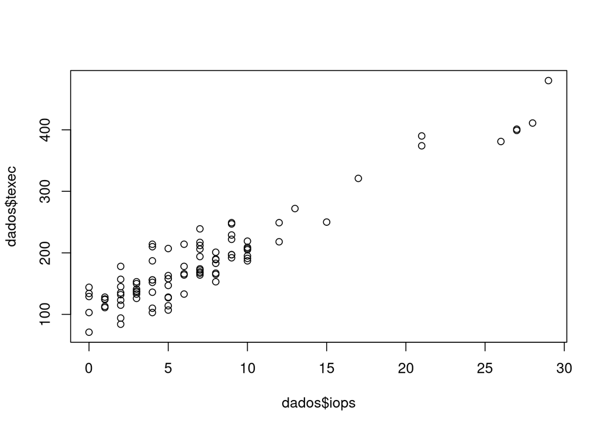

```r
# le os dados do arquivo para o data frame dados
dados <- read.table("texec-iops.dat", header = TRUE)

# 1
# texec.min é o menor elemento da coluna texec
texec.min <- min(dados$texec)
# texec.max é o maior elemento da coluna texec
texec.max <- max(dados$texec)

# 2
# texec.avg é a média de texec
texec.avg <- mean(dados$texec)
# arredonda para uma casa decimal
texec.avg <- round(texec.avg, 1)

# 3
# iops.med é a mediana da coluna iops
iops.med <- median(dados$iops)

# 4
# iops.0 é o número de valores 0 em iops
iops.0 <- length(dados$iops[dados$iops == 0])

# 5
# dados.300 contém apenas as linhas com texec mínimo de 300
# iops.300.avg é a média de iops em dados.300
dados.300 <- dados[dados$texec >= 300,]
iops.300.avg <- mean(dados.300$iops)
iops.300.avg <- round(iops.300.avg, 1)   # arredonda para uma casa decimal

# 6
with(dados, plot(dados$iops, dados$texec))
```

Respostas:

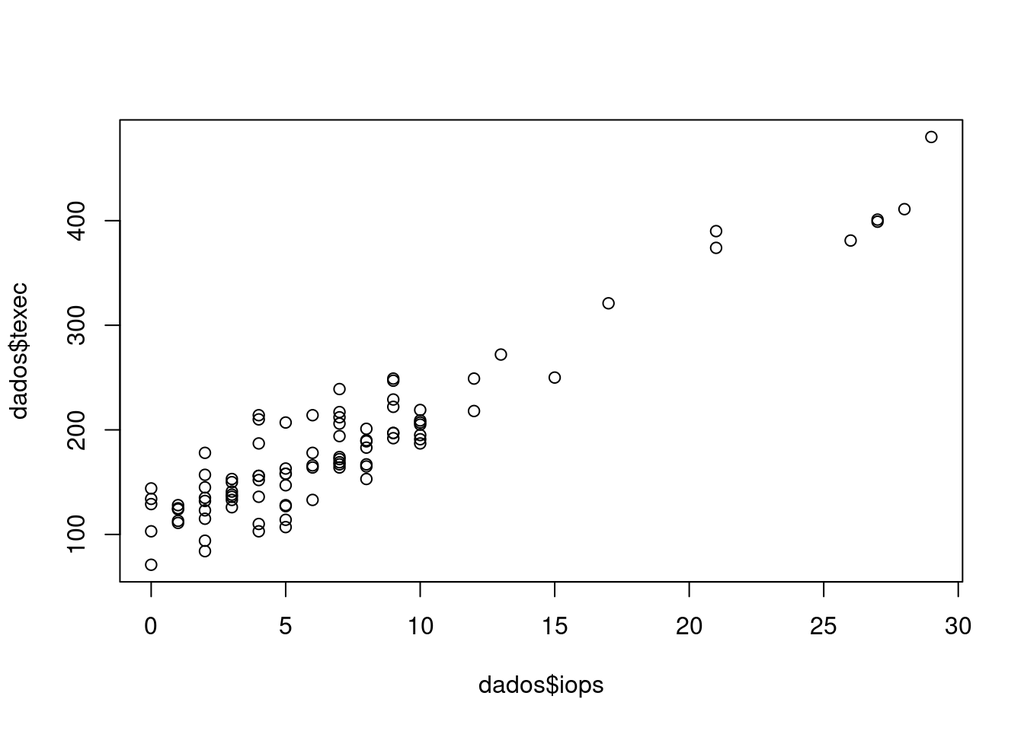

```r
with(dados, plot(dados$iops, dados$texec))
```

- O tempo de execução tende a aumentar de acordo com número de operações.

## Análise do conjunto `mtcars`

Diversos conjuntos de dados podem ser encontrados em qualquer instalação de R, e podem ser acessados diretamente pelo seu nome.[^1] Um deles é `mtcars`, que traz 11 características de 32 carros publicadas na revista americana *Motor Trend*. Você pode visualizar o conjunto com `View(mtcars)`, e consultar a descrição de cada variável usando o comando `?mtcars`. Neste exercício você irá analisar algumas dessas variáveis.

Usando o conjunto `mtcars`, responda às seguintes questões:

1. A variável `hp` representa a potência do motor. Qual carro tem o motor mais potente, e qual é a sua potência? E o motor menos potente?
2. A variável `am` indica o tipo de transmissão (0=automática, 1=manual). Qual carro com transmissão automática é o mais potente?
3. A variável `mpg` representa o consumo de combustível (em milhas por galão, 1 mpg = 0,425 km/l). É possível afirmar que o consumo médio de carros automáticos é maior que, menor que, ou igual ao consumo de carros com transmissão manual?
4. Quais carros possuem consumo igual ou melhor que 12 km/l?
5. A variável `qsec` representa o tempo (em segundos) para percorrer 1/4 de milha, e a variável `vs` indica a disposição dos cilindros do motor (0=cilindros em V, 1=cilindros em linha). Com base nos dados, é possível afirmar que motores com cilindros em V têm melhor desempenho (em termos de `qsec`) do que motores com cilndros em linha?
6. A variável `wt` representa o peso (em milhares de libras). Com base nos dados, como você diria que o peso afeta o consumo? (Dica: faça um gráfico de dispersão de consumo x peso.)
7. A variável `gear` representa o número de marchas. Com bsae nos dados, é possível afirmar que carros com mais marchas são mais (ou menos) potentes?

Código e saídas do R:

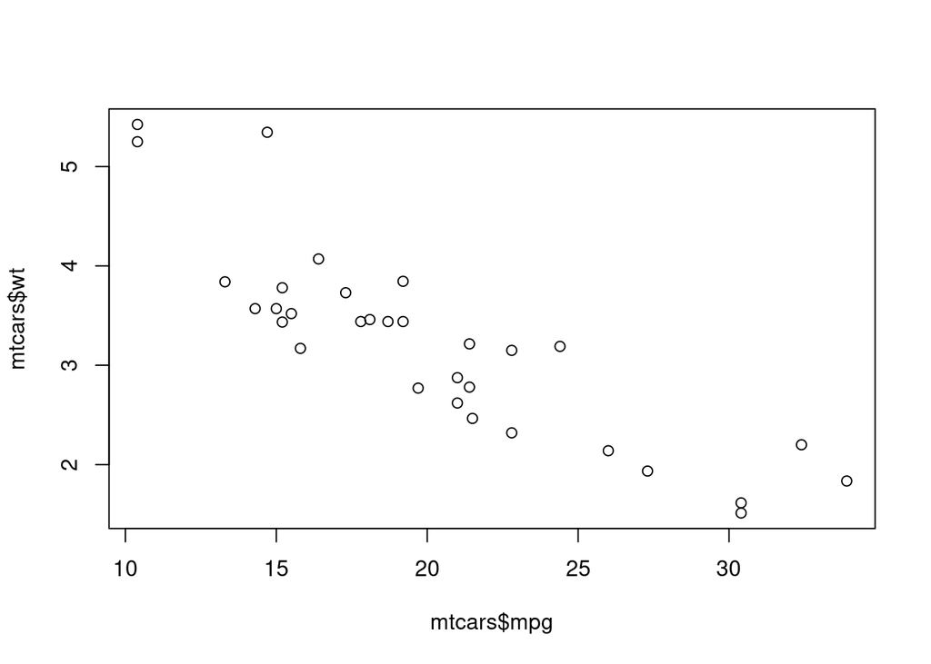

```r
# seu codigo R vai aqui
mtcars.hp.max <- max(mtcars$hp)
mtcars.hp.min <- min(mtcars$hp)

mtcars.hp.maxcar <- mtcars[mtcars$hp == mtcars.hp.max,]
mtcars.hp.mincar <- mtcars[mtcars$hp == mtcars.hp.min,]

mtcars.automatic <- mtcars[mtcars$am == 0,]
mtcars.automatic.hp.maxcar <- mtcars.automatic[mtcars.automatic$hp == max(mtcars.automatic$hp),]

mtcars.manual <- mtcars[mtcars$am == 1,]
mtcars.automatic.meanmpg <- mean(mtcars.automatic$mpg)
mtcars.manual.meanmpg <- mean(mtcars.manual$mpg)

mtcars.meanmpg.txt <- 'Maior' # is default
if (mtcars.automatic.meanmpg == mtcars.manual.meanmpg) {
  mtcars.meanmpg.txt <- 'Igual'
}

if (mtcars.automatic.meanmpg > mtcars.manual.meanmpg) {
  mtcars.bigger.meanmpg <- 'Automáticos'
  mtcars.minor.meanmpg <- 'Manuais'
} else {
  mtcars.bigger.meanmpg <- 'Manuais'
  mtcars.minor.meanmpg <- 'Automáticos'
}

mpg_kg <- 0.425
km_l_12 <- 12 / mpg_kg
mtcars.mpg.km_l_12 <- mtcars[mtcars$mpg >= km_l_12,]

mtcars.vs.v <- mtcars[mtcars$vs == 0,]
mtcars.vs.line <- mtcars[mtcars$vs == 1,]

mtcars.vs.v.mean <- mean(mtcars.vs.v$qsec)
mtcars.vs.line.mean <- mean(mtcars.vs.line$qsec)

mtcars.vs.type <- 'Maior'
if (mtcars.vs.line.mean == mtcars.vs.v.mean) {
  mtcars.vs.type <- 'Igual'
}

if (mtcars.vs.line.mean < mtcars.vs.v.mean) {
  mtcars.bigger.qsecmean <- 'V'
  mtcars.minor.qsecmean <- 'Linha'
} else {
  mtcars.bigger.qsecmean <- 'Linha'
  mtcars.minor.qsecmean <- 'V'
}

with(mtcars, plot(mtcars$mpg, mtcars$wt))
```

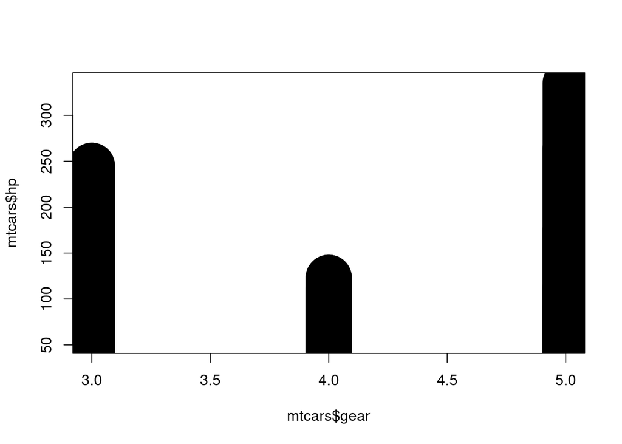

```r
with(mtcars, plot(mtcars$gear, mtcars$hp, type = 'h', lwd = 50))
```

```r
gears <- sort(unique(mtcars$gear))
```

Respostas:

1. Resposta da questão 1
- O carro mais pontente é o Maserati Bora
- O carro menos potente é o Honda Civic
2. Resposta da questão 2
- Os carros com a transmissão automática mais potente são os Duster 360, Camaro Z28
3. Resposta da questão 3
- A média de consumo dos carros manuais é de 24.3923077
- A média de consumo dos carros automáticos é de 17.1473684
- Os carros Manuais tem uma média de consumo Maior do que os Automáticos
4. Resposta da questão 4
- Os carros que possuem consumo igual ou maior que 12 km/l são: Fiat 128, Honda Civic, Toyota Corolla, Lotus Europa
5. Resposta da questão 5
- A média do tempo em segundos para percorrer 1/4 de milha dos carros de cilindro v é 16.6938889
- A média do tempo em segundos para percorrer 1/4 de milha dos carros de cilindro em linha é 19.3335714
- Os carros com cilindro em Linha tem a média do tempo em segundos Maior do que os de cilindro V para percorrer 1/4 de milha. Então, na média os carros com cilindro V tem um desempenho melhor que os de cilindro Linha
6. Resposta da questão 6

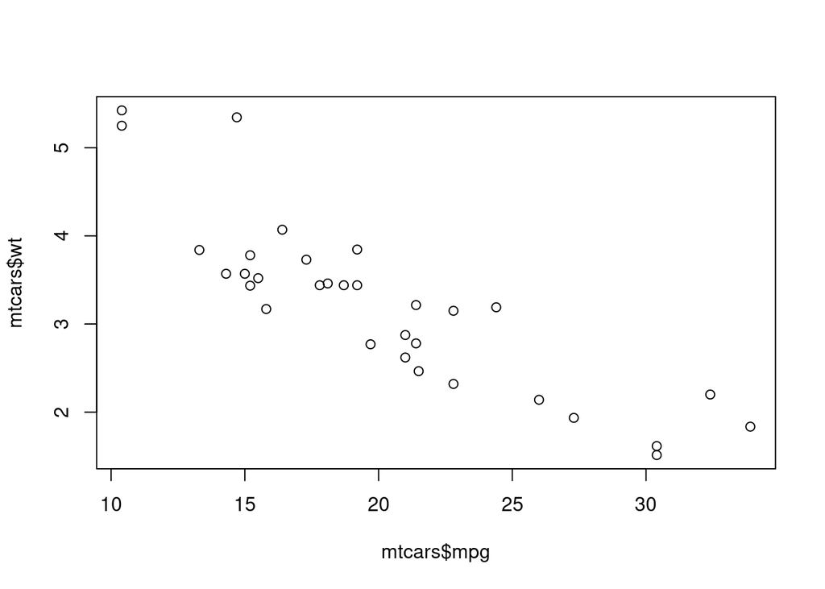

```r
with(mtcars, plot(mtcars$mpg, mtcars$wt))
```

- O peso do carro tende a prejudicar o consumo do carro, então qual mais pesado o carro, maior a probabilidade que o consumo do carro tenha um desempenho pior
7. Resposta da questão 7

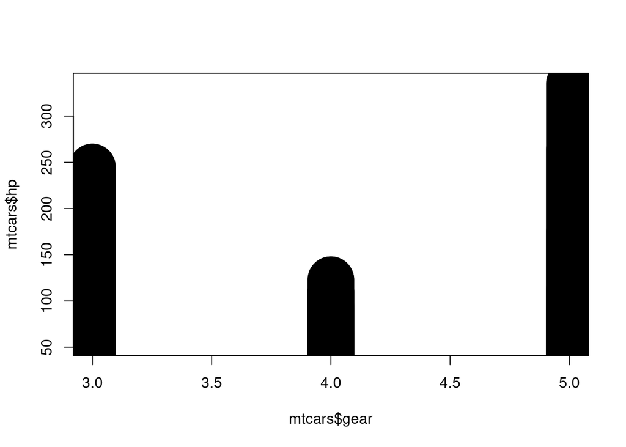

```r
with(mtcars, plot(mtcars$gear, mtcars$hp, type = 'h', lwd = 50))
```

- Na verdade, não é possível definir que carros com mais marchas tem mais potência no motor, pois temos carros com 3, 4, 5 marchas e na verdade, os carros com menor marchas 3 tem uma potência melhor que os 4, mas os carros com uma potência de motor maior são os com 5

## Análise do conjunto `WWWusage`

O conjunto `WWWusage` contém uma série de 100 medições do número de usuários conectados à Internet através de um servidor a cada minuto. Usando esse conjunto, responda às seguintes questões:

1. Em que minuto o servidor teve a maior carga, e qual foi essa carga?
2. Em que minuto o servidor teve a menor carga, e qual foi essa carga?
3. Em que minuto o servidor teve o maior aumento de carga? Qual foi esse aumento (de quantos para quantos usuários)?
4. Em que minuto o servidor teve a maior redução de carga? Qual foi essa redução (de quantos para quantos usuários)?
5. Quantas vezes o número de usuários manteve-se constante em duas medições consecutivas?
6. Determine o número de usuários para o minuto 101, supondo que um eventual aumento ou redução de carga não ultrapasse os valores máximos obtidos nas questões 3 e 4. (Dica: você deverá estimar uma faixa de valores.)

Código e saídas do R:

```r
# seu codigo R vai aqui

WWWusage.max <- max(WWWusage)
WWWusage.max.which <- which(WWWusage == WWWusage.max)

WWWusage.min <- min(WWWusage)
WWWusage.min.which <- which(WWWusage == WWWusage.min)

WWWusage.diff <- diff(WWWusage)
WWWusage.diff.max <- max(WWWusage.diff)
WWWusage.diff.max.which <- which(WWWusage.diff == WWWusage.diff.max)

WWWusage.diff.min <- min(WWWusage.diff)
WWWusage.diff.min.which <- which(WWWusage.diff == WWWusage.diff.min)

WWWusage.diff.consecutive <- WWWusage.diff[WWWusage.diff == 0]
WWWusage.last <- WWWusage[length(WWWusage)]

WWWusage.last.plusdif <- WWWusage.last + WWWusage.diff.max
WWWusage.last.minusdif <- WWWusage.last - WWWusage.diff.max

WWWusage.next.max <- min(WWWusage.last.plusdif, WWWusage.max)
WWWusage.next.min <- max(WWWusage.last.minusdif, WWWusage.min)

summary(WWWusage)
```

```
##    Min. 1st Qu.  Median    Mean 3rd Qu.    Max.
##    83.0    99.0   138.5   137.1   167.5   228.0
```

```r
HoltWinters(WWWusage, beta=FALSE, gamma=FALSE)
```

```
## Holt-Winters exponential smoothing without trend and without seasonal component.
##
## Call:
## HoltWinters(x = WWWusage, beta = FALSE, gamma = FALSE)
##
## Smoothing parameters:
##  alpha: 0.99992
##  beta : FALSE
##  gamma: FALSE
##
## Coefficients:
##       [,1]
## a 220.0002
```

Respostas:

1. Resposta da questão 1
- No minuto 97 o servidor teve a maior carga de 228
2. Resposta da questão 2
- No minuto 7 o servidor teve a menor carga de 83
3. Resposta da questão 3
- Nos minutos 14, 81 para os 15, 82 teve um aumento de 14 usuários
4. Resposta da questão 4
- No minuto 57 para o minuto 58 teve uma redução de 14 usuários
5. Resposta da questão 5
- 9 vezes o número de usuários manteve-se com duas medições consecutivas
6. Resposta da questão 6

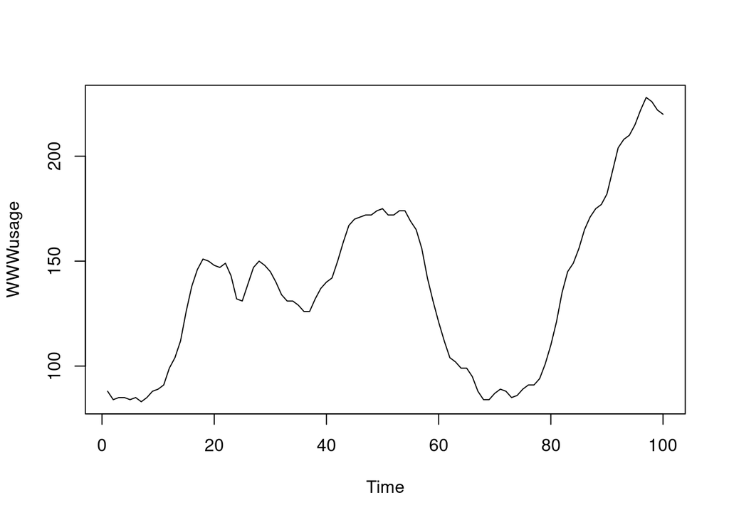

```r
plot(WWWusage)
```

- Para estimar o numero de usuarios para o minuto 101, levando em consideração o maior aumento de usuários ja registrado 14 entre um minuto e outro e o ultimo valor registrado de 220 usuários, e também a mínima 83 e máxima 228, o range provável do minuto 101 será entre 206 e 228.
- Ja HoltWinters estima o seguinte valor:

```r
HoltWinters(WWWusage, beta=FALSE, gamma=FALSE)
```

```
## Holt-Winters exponential smoothing without trend and without seasonal component.
##
## Call:
## HoltWinters(x = WWWusage, beta = FALSE, gamma = FALSE)
##
## Smoothing parameters:
##  alpha: 0.99992
##  beta : FALSE
##  gamma: FALSE
##
## Coefficients:
##       [,1]
## a 220.0002
```

[^1]: O comando `data()` mostra uma lista dos conjuntos disponíveis.